# CreditCard_Fraud_2

### Step 2: Feature engineering & Modelling

```python
# Load libraries

!pip install plotly

import pandas as pd
import numpy as np
import matplotlib.pyplot as plt
import seaborn as sns
import plotly.express as px
import warnings
import plotly.express as px

warnings.filterwarnings('ignore')
plt.style.use('seaborn-v0_8')
sns.set_palette("coolwarm")
```

```python
# Load datasets

credit = pd.read_csv("/mnt/c/1.MorganeCanada/Project-2-/Data/CreditCard_FraudDetection.csv")

print("CREDIT CARD DATA")
print("Shape:", credit.shape)
print(credit.head())
print("\nColumns:", credit.columns)

print("\n" + "="*60 + "\n")
```

```
CREDIT CARD DATA
Shape: (284807, 31)
   Time        V1        V2        V3        V4        V5        V6        V7  \
0   0.0 -1.359807 -0.072781  2.536347  1.378155 -0.338321  0.462388  0.239599
1   0.0  1.191857  0.266151  0.166480  0.448154  0.060018 -0.082361 -0.078803
2   1.0 -1.358354 -1.340163  1.773209  0.379780 -0.503198  1.800499  0.791461
3   1.0 -0.966272 -0.185226  1.792993 -0.863291 -0.010309  1.247203  0.237609
4   2.0 -1.158233  0.877737  1.548718  0.403034 -0.407193  0.095921  0.592941

         V8        V9  ...       V21       V22       V23       V24       V25  \
0  0.098698  0.363787  ... -0.018307  0.277838 -0.110474  0.066928  0.128539
1  0.085102 -0.255425  ... -0.225775 -0.638672  0.101288 -0.339846  0.167170
2  0.247676 -1.514654  ...  0.247998  0.771679  0.909412 -0.689281 -0.327642
3  0.377436 -1.387024  ... -0.108300  0.005274 -0.190321 -1.175575  0.647376
4 -0.270533  0.817739  ... -0.009431  0.798278 -0.137458  0.141267 -0.206010

        V26       V27       V28  Amount  Class
0 -0.189115  0.133558 -0.021053  149.62      0
1  0.125895 -0.008983  0.014724    2.69      0
2 -0.139097 -0.055353 -0.059752  378.66      0
3 -0.221929  0.062723  0.061458  123.50      0
4  0.502292  0.219422  0.215153   69.99      0

[5 rows x 31 columns]

Columns: Index(['Time', 'V1', 'V2', 'V3', 'V4', 'V5', 'V6', 'V7', 'V8', 'V9', 'V10',
       'V11', 'V12', 'V13', 'V14', 'V15', 'V16', 'V17', 'V18', 'V19', 'V20',
       'V21', 'V22', 'V23', 'V24', 'V25', 'V26', 'V27', 'V28', 'Amount',
       'Class'],
      dtype='object')

============================================================
```

**FEATURE ENGINEERING FOR CREDIT CARD FRAUD DATA**

```python
# Convert time in seconds to hours (0–23)

credit['hour'] = (credit['Time'] // 3600) % 24

# Night transactions between 10 PM and 6 AM

credit['is_night'] = credit['hour'].apply(lambda x: 1 if (x >= 22 or x <= 6) else 0)

# Log transform of Amount to reduce skew

credit['amount_log'] = np.log1p(credit['Amount'])
```

```python
# Check for missing values and Balance

print("\nMissing values in Credit Card:")
print(credit.isna().sum().sum())

print("\nClass balance in Credit Card:")
print(credit["Class"].value_counts())
```

```
Missing values in Credit Card:
0

Class balance in Credit Card:
Class
0    284315
1       492
Name: count, dtype: int64
```

```python
# Check the new data set

print("CREDIT CARD DATA")
print("Shape:", credit.shape)
print(credit.head())
print("\nColumns:", credit.columns)

print("\n" + "="*60 + "\n")

print("Hour distribution:")
print(credit['hour'].value_counts().sort_index())

print("\nNight transactions count:")
print(credit['is_night'].value_counts())
```

```
CREDIT CARD DATA
Shape: (284807, 34)
   Time        V1        V2        V3        V4        V5        V6        V7  \
0   0.0 -1.359807 -0.072781  2.536347  1.378155 -0.338321  0.462388  0.239599
1   0.0  1.191857  0.266151  0.166480  0.448154  0.060018 -0.082361 -0.078803
2   1.0 -1.358354 -1.340163  1.773209  0.379780 -0.503198  1.800499  0.791461
3   1.0 -0.966272 -0.185226  1.792993 -0.863291 -0.010309  1.247203  0.237609
4   2.0 -1.158233  0.877737  1.548718  0.403034 -0.407193  0.095921  0.592941

         V8        V9  ...       V24       V25       V26       V27       V28  \
0  0.098698  0.363787  ...  0.066928  0.128539 -0.189115  0.133558 -0.021053
1  0.085102 -0.255425  ... -0.339846  0.167170  0.125895 -0.008983  0.014724
2  0.247676 -1.514654  ... -0.689281 -0.327642 -0.139097 -0.055353 -0.059752
3  0.377436 -1.387024  ... -1.175575  0.647376 -0.221929  0.062723  0.061458
4 -0.270533  0.817739  ...  0.141267 -0.206010  0.502292  0.219422  0.215153

   Amount  Class  hour  is_night  amount_log
0  149.62      0   0.0         1    5.014760
1    2.69      0   0.0         1    1.305626
2  378.66      0   0.0         1    5.939276
3  123.50      0   0.0         1    4.824306
4   69.99      0   0.0         1    4.262539

[5 rows x 34 columns]

Columns: Index(['Time', 'V1', 'V2', 'V3', 'V4', 'V5', 'V6', 'V7', 'V8', 'V9', 'V10',
       'V11', 'V12', 'V13', 'V14', 'V15', 'V16', 'V17', 'V18', 'V19', 'V20',
       'V21', 'V22', 'V23', 'V24', 'V25', 'V26', 'V27', 'V28', 'Amount',
       'Class', 'hour', 'is_night', 'amount_log'],
      dtype='object')

============================================================

Hour distribution:
hour
0.0      7695
1.0      4220
2.0      3328
3.0      3492
4.0      2209
```

[output cut: 11 more lines]

```
16.0    16453
17.0    16166
18.0    17039
19.0    15649
20.0    16756
21.0    17703
22.0    15441
23.0    10938
Name: count, dtype: int64

Night transactions count:
is_night
0    230393
1     54414
Name: count, dtype: int64
```

*Are there more frauds during the night?*

```python
# Total amount of frauds.

fraud_df = credit[credit["Class"] == 1]
print("Total fraudulent transactions:", len(fraud_df))

# At night?

fraud_night_counts = fraud_df["is_night"].value_counts()
print("Fraud count by night/day:")
print(fraud_night_counts)

fraud_night_percent = fraud_df["is_night"].value_counts(normalize=True) * 100
print("\nFraud percentage by night/day:")
print(fraud_night_percent)

# Particular Hour?

fraud_by_hour = fraud_df.groupby("hour").size()
print(fraud_by_hour)
```

```
Total fraudulent transactions: 492
Fraud count by night/day:
is_night
0    329
1    163
Name: count, dtype: int64

Fraud percentage by night/day:
is_night
0    66.869919
1    33.130081
Name: proportion, dtype: float64
hour
0.0      6
1.0     10
2.0     57
3.0     17
4.0     23
5.0     11
6.0      9
7.0     23
8.0      9
9.0     16
10.0     8
11.0    53
12.0    17
13.0    17
14.0    23
15.0    26
16.0    22
17.0    29
18.0    33
19.0    19
20.0    18
21.0    16
22.0     9
23.0    21
dtype: int64
```

**Balance and scale the dataset & Predict with Machine Learning**

```python
# Separate features & target

X = credit.drop("Class", axis=1)
y = credit["Class"]

# Train/test split (ALWAYS before balancing)

from sklearn.model_selection import train_test_split

X_train, X_test, y_train, y_test = train_test_split(
    X, y,
    test_size=0.2,
    stratify=y, # keeps same fraud ratio in test set
    random_state=42
)

# Scale the data !!! Fit only on train, then transform both.

from sklearn.preprocessing import StandardScaler

scaler = StandardScaler()

X_train_scaled = scaler.fit_transform(X_train)
X_test_scaled = scaler.transform(X_test)

# Balance the training set (SMOTE – best for fraud)

!pip install imbalanced-learn

from imblearn.over_sampling import SMOTE

smote = SMOTE(random_state=42)
X_train_balanced, y_train_balanced = smote.fit_resample(X_train_scaled, y_train)

print("Before balancing:", y_train.value_counts())
print("After balancing:", pd.Series(y_train_balanced).value_counts())
```

```
Before balancing: Class
0    227451
1       394
Name: count, dtype: int64
After balancing: Class
0    227451
1    227451
Name: count, dtype: int64
```

*Logistic Linear Regression*

```python
from sklearn.linear_model import LogisticRegression
from sklearn.metrics import classification_report

model = LogisticRegression(max_iter=1000)
model.fit(X_train_balanced, y_train_balanced)

y_pred = model.predict(X_test_scaled)

print(classification_report(y_test, y_pred))
```

```
              precision    recall  f1-score   support

           0       1.00      0.97      0.99     56864
           1       0.06      0.92      0.10        98

    accuracy                           0.97     56962
   macro avg       0.53      0.95      0.55     56962
weighted avg       1.00      0.97      0.98     56962
```

**Interpretation**

**Key Takeaways:**

My model is acting like this: “If I think it might be fraud, I’ll just call it fraud.” So it catches most frauds **BUT** it also flags huge numbers of normal transactions as fraud.

**This would:**

- Annoy customers
- Block legit cards
- Cause false alarms

*Because I used SMOTE or balancing, the model became very sensitive to fraud examples but cannot differentiate well enough yet*

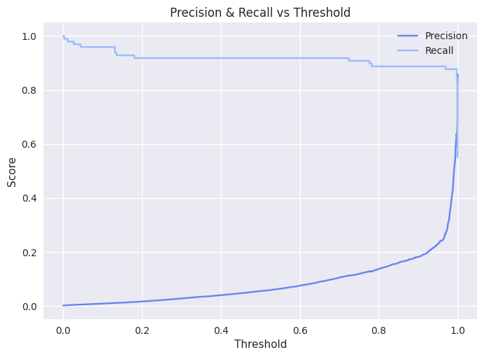

```python
# Precision recall curve

from sklearn.metrics import precision_recall_curve

# Define y probs
y_probs = model.predict_proba(X_test_scaled)[:, 1]

precision, recall, th = precision_recall_curve(y_test, y_probs)

plt.figure()
plt.plot(th, precision[:-1], label="Precision")
plt.plot(th, recall[:-1], label="Recall")

plt.xlabel("Threshold")
plt.ylabel("Score")
plt.title("Precision & Recall vs Threshold")
plt.legend()
plt.show()
```

```python
# Model again with the best threshold

best_threshold = 0.90

y_pred_tuned = (y_probs >= best_threshold).astype(int)

from sklearn.metrics import classification_report

print(classification_report(y_test, y_pred_tuned))
```

```
              precision    recall  f1-score   support

           0       1.00      0.99      1.00     56864
           1       0.18      0.89      0.30        98

    accuracy                           0.99     56962
   macro avg       0.59      0.94      0.65     56962
weighted avg       1.00      0.99      1.00     56962
```

**The model is doing ok but not great** Linear models are limited when classes overlap heavily or the minority class is very sparse.

*Modelling with Random Forest*

```python
from sklearn.ensemble import RandomForestClassifier
from sklearn.metrics import classification_report, precision_recall_curve, f1_score
from imblearn.over_sampling import SMOTE

X_train_res, y_train_res = X_train, y_train  # Replace if SMOTE needed

# Initialize Random Forest with balanced class weights

rf = RandomForestClassifier(
    n_estimators=500,        # more trees improve stability
    max_depth=None,          # let trees grow fully, prevents underfitting
    min_samples_split=5,     # avoids overfitting to tiny nodes
    min_samples_leaf=2,      # ensures each leaf has enough samples
    max_features='sqrt',     # reduces correlation among trees
    class_weight='balanced', # handles imbalance automatically
    random_state=42,
    n_jobs=-1
)

# Train the model

rf.fit(X_train_res, y_train_res)

# Instead of the default 0.5, pick the threshold that maximises the F1-score for class 1:
# Predict probabilities for the positive class

y_probs = rf.predict_proba(X_test)[:, 1]

# Calculate precision, recall, thresholds

precisions, recalls, thresholds = precision_recall_curve(y_test, y_probs)

# Compute F1 for each threshold

f1_scores = 2 * precisions * recalls / (precisions + recalls + 1e-8)
best_idx = f1_scores.argmax()
best_threshold = thresholds[best_idx]

print("Best threshold for max F1:", best_threshold)

# Apply threshold
y_pred_tuned = (y_probs >= best_threshold).astype(int)

# Evaluate

print(classification_report(y_test, y_pred_tuned))

# Hyperparameter tunning

param_grid = {
    'n_estimators': [300, 500, 700],
    'max_depth': [None, 10, 20, 30],
    'min_samples_split': [2, 5, 10],
    'min_samples_leaf': [1, 2, 4],
    'max_features': ['sqrt', 'log2', None]
}
```

```
Best threshold for max F1: 0.4197894472112458
              precision    recall  f1-score   support

           0       1.00      1.00      1.00     56864
           1       0.94      0.82      0.87        98

    accuracy                           1.00     56962
   macro avg       0.97      0.91      0.94     56962
weighted avg       1.00      1.00      1.00     56962
```

**Interpretation:**

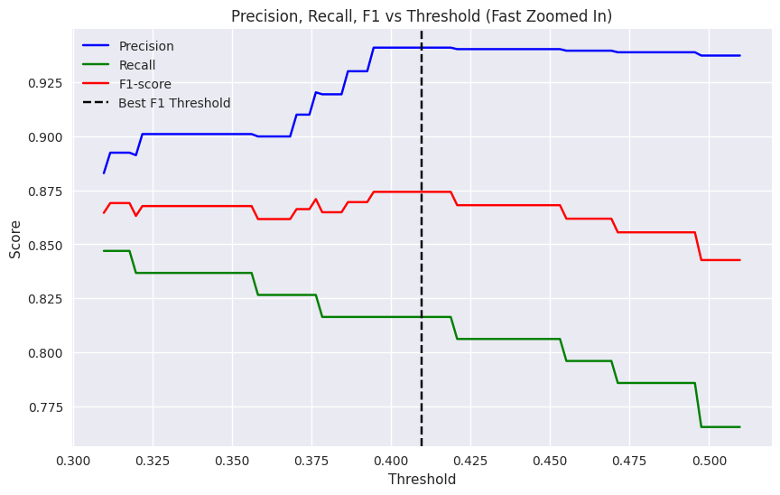

```python
from sklearn.metrics import precision_score, recall_score

# Define zoom range around best threshold

best_threshold = 0.4097
zoom_margin = 0.1
thresholds_zoom = np.linspace(best_threshold - zoom_margin, best_threshold + zoom_margin, 100)

# Compute precision, recall, F1 for each threshold

precisions = []
recalls = []
f1_scores = []

for t in thresholds_zoom:
    y_pred = (y_probs >= t).astype(int)
    precisions.append(precision_score(y_test, y_pred))
    recalls.append(recall_score(y_test, y_pred))
    f1_scores.append(f1_score(y_test, y_pred))

# Plot
plt.figure(figsize=(10,6))
plt.plot(thresholds_zoom, precisions, label='Precision', color='blue')
plt.plot(thresholds_zoom, recalls, label='Recall', color='green')
plt.plot(thresholds_zoom, f1_scores, label='F1-score', color='red')
plt.axvline(x=best_threshold, color='black', linestyle='--', label='Best F1 Threshold')
plt.xlabel('Threshold')
plt.ylabel('Score')
plt.title('Precision, Recall, F1 vs Threshold (Fast Zoomed In)')
plt.legend()
plt.grid(True)
plt.show()
```

**Add Cost-Sensitive Learning & Business Impact**

```python
# Define assumed business costs

# Business cost assumptions (adjust as needed)
C_FN = credit['Amount'].mean() * 4     # average fraud amount × multiplier
C_FP = 5                                # estimated cost of blocking legit customer ($5–$10 typical)

# Compute confusion matrix
from sklearn.metrics import confusion_matrix

tn, fp, fn, tp = confusion_matrix(y_test, y_pred_tuned).ravel()

print("Confusion Matrix:")
print("TN:", tn)
print("FP:", fp)
print("FN:", fn)
print("TP:", tp)

# Calculate Total Economic Cost
total_cost = (fn * C_FN) + (fp * C_FP)

print(f"Estimated Financial Cost of Model Errors: ${total_cost:,.2f}")

# Compare with baseline (predicting all 0’s)
# Baseline model: predict NO fraud always → all fraud becomes FN
fn_baseline = sum(y_test == 1)
fp_baseline = 0

baseline_cost = (fn_baseline * C_FN) + (fp_baseline * C_FP)

print(f"Baseline Cost (No Model): ${baseline_cost:,.2f}")
print(f"Cost Savings Thanks to Model: ${baseline_cost - total_cost:,.2f}")
```

```
Confusion Matrix:
TN: 56859
FP: 5
FN: 18
TP: 80
Estimated Financial Cost of Model Errors: $6,386.17
Baseline Cost (No Model): $34,633.05
Cost Savings Thanks to Model: $28,246.88
```

**Interpretation**

Our fraud detection model drastically reduces financial losses. By catching 80 fraudulent transactions while only blocking 5 legitimate ones, the estimated cost of errors drops from $34,633 (if we did nothing) to just $6,386. This translates to over $28,000 in savings, showing that even a small improvement in fraud detection can have a huge impact on the bottom line. Adjusting the model threshold allows us to balance catching more fraud against the risk of inconveniencing real customers.

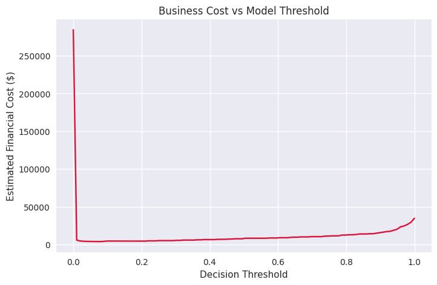

```python
# Predicted probabilities
y_proba = rf.predict_proba(X_test)[:,1]

thresholds = np.linspace(0, 1, 100)
costs = []

for t in thresholds:
    y_pred_thresh = (y_proba >= t).astype(int)
    tn, fp, fn, tp = confusion_matrix(y_test, y_pred_thresh).ravel()
    total_cost = fn * C_FN + fp * C_FP
    costs.append(total_cost)

plt.figure(figsize=(8,5))
plt.plot(thresholds, costs, color='crimson')
plt.xlabel("Decision Threshold")
plt.ylabel("Estimated Financial Cost ($)")
plt.title("Business Cost vs Model Threshold")
plt.grid(True)
plt.show()
```

**This plot lets stakeholders see how adjusting the threshold affects total cost, making the business impact very tangible.**

The minimum point of the curve is where the model is most cost-effective.

```python
# Save your RF parameters

import joblib

model_artifacts = {
    "rf": rf,
    "best_threshold": best_threshold,
    "feature_names": rf.feature_names_in_,
    "C_FN": C_FN,
    "C_FP": C_FP,
    "X_test_scaled": X_test_scaled,
    "y_test": y_test,
    "X_train_res": X_train_res,
    "y_train_res": y_train_res,
    "y_train": y_train,
    "X_train_scaled": X_train_scaled
}

joblib.dump(model_artifacts, "fraud_randomforest_artifacts.pkl")
```

```
['fraud_randomforest_artifacts.pkl']
```